# Разработка A/B-тестирования и анализ результатов

Компания разрабатывает развлекательное приложение с функцией «бесконечной» ленты. В приложении существует две модели монетизации: первая — ежемесячная платная подписка, которая позволяет пользователям смотреть ленту без рекламы, вторая — демонстрация рекламы для пользователей, которые ещё не оформили подписку.

Команда разработчиков рекомендательных систем создала новый алгоритм рекомендаций, который, по их мнению, будет показывать более интересный контент для каждого пользователя. Требуется рассчитать параметры A/B-теста, который позволит проверить эту гипотезу, и проанализировать его результаты.

## Задача

Рассчитать параметры теста, оценить корректность его проведения и проанализировать результаты эксперимента.

### 1. Работа с историческими данными (EDA)

#### 1.1. Загрузка исторических данных

На первом этапе поработаем с историческими данными приложения: Импортируем необходимые библиотеки и посмотрим на данные.

```python
# Импортируем библиотеку
import pandas as pd
```

```python
# Выгружаем данные в переменную
sessions_history = pd.read_csv('https://code.s3.yandex.net/datasets/sessions_project_history.csv')
```

```python
# Выводим первые 5 строк
sessions_history.head()
```

|  | user_id | session_id | session_date | session_start_ts | install_date | session_number | registration_flag | page_counter | region | device |
| --- | --- | --- | --- | --- | --- | --- | --- | --- | --- | --- |
| 0 | E302123B7000BFE4 | F9AF61A0C2023832 | 2025-08-15 | 2025-08-15 17:47:35 | 2025-08-15 | 1 | 0 | 3 | CIS | iPhone |
| 1 | 2530F72E221829FB | 85003A206CBDAC6F | 2025-08-15 | 2025-08-15 16:42:14 | 2025-08-15 | 1 | 0 | 4 | MENA | Android |
| 2 | 876E020A4FC512F5 | 3677423E49D72DEE | 2025-08-15 | 2025-08-15 12:30:00 | 2025-08-15 | 1 | 0 | 4 | EU | PC |
| 3 | 2640B349E1D81584 | 956B45F5915CA225 | 2025-08-15 | 2025-08-15 15:31:31 | 2025-08-15 | 1 | 0 | 4 | CIS | Android |
| 4 | 94E1CBFAEF1F5EE9 | 83BF0DA35F9F1F40 | 2025-08-15 | 2025-08-15 21:33:53 | 2025-08-15 | 1 | 0 | 3 | CIS | Android |

#### 1.2. Знакомство с данными

- Для каждого уникального пользователя `user_id` рассчитаем количество уникальных сессий `session_id`.
- Находём пользователя с наибольшим количеством сессий
- Изучим таблицу для одного пользователя, чтобы лучше понять логику формирования каждого столбца данных.

```python
# Рассчитываем количество уникальных сессий для каждого пользователя
user_session_counts = sessions_history.groupby("user_id")["session_id"].nunique()

# Выводим первые 5 результатов
user_session_counts.head()
```

```
user_id
00005FB6A13A6FBE    2
0000B15A18D77ED9    3
0000C4E3A4A571A9    2
000293FAF9E67A81    4
00029C5AE889A6C3    2
Name: session_id, dtype: int64
```

```python
# Находим пользователя с наибольшим количеством сессий
top_user_id = user_session_counts.idxmax()
# Фильтруем данные по этому пользователю
top_user_sessions = sessions_history[sessions_history["user_id"] == top_user_id]

# Выводим результат
top_user_sessions
```

|  | user_id | session_id | session_date | session_start_ts | install_date | session_number | registration_flag | page_counter | region | device |
| --- | --- | --- | --- | --- | --- | --- | --- | --- | --- | --- |
| 115558 | 10E0DEFC1ABDBBE0 | B8F0423BBFFCF5DC | 2025-08-14 | 2025-08-14 13:57:39 | 2025-08-14 | 1 | 0 | 4 | CIS | Android |
| 191751 | 10E0DEFC1ABDBBE0 | 87CA2FA549473837 | 2025-08-15 | 2025-08-15 16:42:10 | 2025-08-14 | 2 | 0 | 3 | CIS | Android |
| 239370 | 10E0DEFC1ABDBBE0 | 4ADD8011DCDCE318 | 2025-08-16 | 2025-08-16 19:53:21 | 2025-08-14 | 3 | 0 | 3 | CIS | Android |
| 274629 | 10E0DEFC1ABDBBE0 | DF0FD0E09BF1F3D7 | 2025-08-17 | 2025-08-17 15:03:43 | 2025-08-14 | 4 | 0 | 1 | CIS | Android |
| 302501 | 10E0DEFC1ABDBBE0 | 3C221774B4DE6885 | 2025-08-18 | 2025-08-18 17:29:14 | 2025-08-14 | 5 | 0 | 4 | CIS | Android |
| 325557 | 10E0DEFC1ABDBBE0 | 031BD7A67048105B | 2025-08-19 | 2025-08-19 13:23:55 | 2025-08-14 | 6 | 0 | 2 | CIS | Android |
| 345336 | 10E0DEFC1ABDBBE0 | FF4315CF4AD4B100 | 2025-08-20 | 2025-08-20 19:31:54 | 2025-08-14 | 7 | 0 | 2 | CIS | Android |
| 377532 | 10E0DEFC1ABDBBE0 | 4045FEA0747203B4 | 2025-08-22 | 2025-08-22 17:54:13 | 2025-08-14 | 8 | 0 | 2 | CIS | Android |
| 403538 | 10E0DEFC1ABDBBE0 | 344B086C421C7F37 | 2025-08-24 | 2025-08-24 14:46:13 | 2025-08-14 | 9 | 0 | 2 | CIS | Android |
| 414743 | 10E0DEFC1ABDBBE0 | 054F20BA371E4C9D | 2025-08-25 | 2025-08-25 18:36:41 | 2025-08-14 | 10 | 0 | 3 | CIS | Android |

#### 1.3. Анализ числа регистраций

Одна из важнейших метрик продукта — число зарегистрированных пользователей. Посмотрим как менялось число регистраций в приложении за время его существования.

```python
# Преобразуем дату в формат datetime
sessions_history["session_date"] = pd.to_datetime(sessions_history["session_date"])

# Агрегируем данные: считаем уникальных пользователей и зарегистрированных пользователей по дням
daily_stats = sessions_history.groupby("session_date").agg(
    total_users=("user_id", "nunique"),
    registered_users=("registration_flag", "sum")
).reset_index()
daily_stats.head()
```

|  | session_date | total_users | registered_users |
| --- | --- | --- | --- |
| 0 | 2025-08-11 | 3919 | 169 |
| 1 | 2025-08-12 | 6056 | 336 |
| 2 | 2025-08-13 | 8489 | 464 |
| 3 | 2025-08-14 | 10321 | 625 |
| 4 | 2025-08-15 | 14065 | 840 |

```python
# Рассчитываем долю зарегистрированных пользователей
daily_stats["registration_ratio"] = daily_stats["registered_users"] / daily_stats["total_users"]
daily_stats.head()
```

|  | session_date | total_users | registered_users | registration_ratio |
| --- | --- | --- | --- | --- |
| 0 | 2025-08-11 | 3919 | 169 | 0.043123 |
| 1 | 2025-08-12 | 6056 | 336 | 0.055482 |
| 2 | 2025-08-13 | 8489 | 464 | 0.054659 |
| 3 | 2025-08-14 | 10321 | 625 | 0.060556 |
| 4 | 2025-08-15 | 14065 | 840 | 0.059723 |

```python
#Импортируем библиотеку для посторения графиков
import matplotlib.pyplot as plt
```

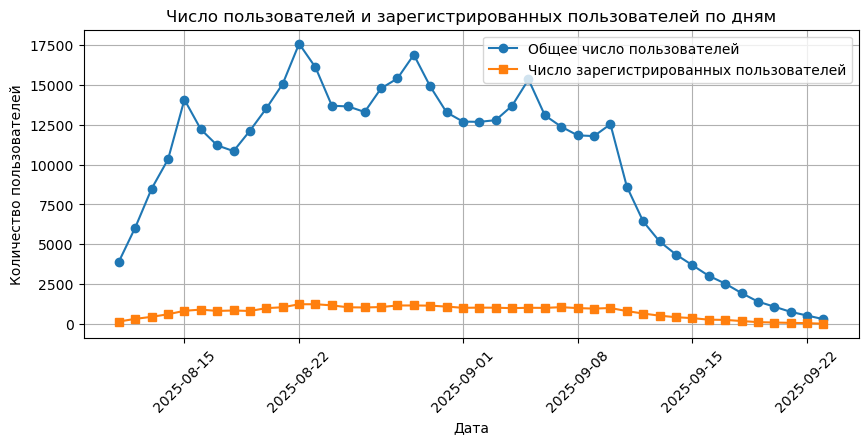

```python
# Строим график общего числа пользователей и зарегистрированных пользователей
plt.figure(figsize=(10, 4))
plt.plot(daily_stats["session_date"], daily_stats["total_users"], label="Общее число пользователей", marker="o")
plt.plot(daily_stats["session_date"], daily_stats["registered_users"], label="Число зарегистрированных пользователей", marker="s")
plt.xlabel("Дата")
plt.ylabel("Количество пользователей")
plt.title("Число пользователей и зарегистрированных пользователей по дням")
plt.legend()
plt.grid(True)
plt.xticks(rotation=45)
plt.show()
```

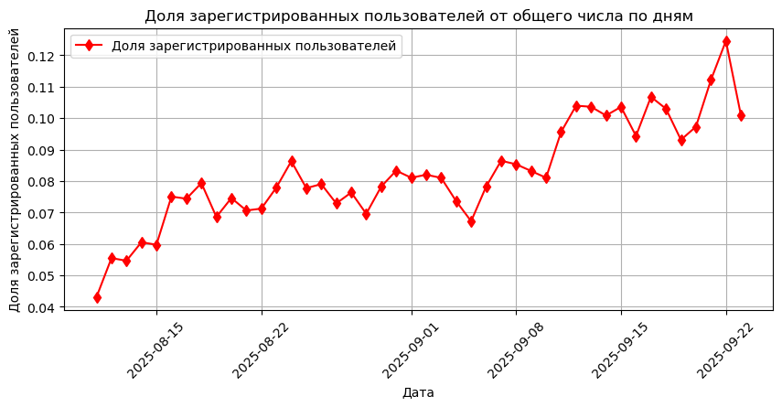

```python
# Строим график доли зарегистрированных пользователей
plt.figure(figsize=(10, 4))
plt.plot(daily_stats["session_date"], daily_stats["registration_ratio"], label="Доля зарегистрированных пользователей", marker="d", color="red")
plt.xlabel("Дата")
plt.ylabel("Доля зарегистрированных пользователей")
plt.title("Доля зарегистрированных пользователей от общего числа по дням")
plt.legend()
plt.grid(True)
plt.xticks(rotation=45)
plt.show()
```

#### 1.4. Анализ числа просмотренных страниц

Другая важная метрика продукта — число просмотренных страниц в приложении. Чем больше страниц просмотрено, тем сильнее пользователь увлечён контентом, а значит, выше шансы на то, что он зарегистрируется и оплатит подписку.

- Найдем количество сессий для каждого значения количества просмотренных страниц.
- Построим визуализацию

```python
# Агрегируем данные: считаем количество сессий для каждого количества просмотренных страниц
page_views_stats = sessions_history["page_counter"].value_counts().reset_index()
page_views_stats.columns = ["page_counter", "session_count"]
# Сортируем по количеству просмотренных страниц
page_views_stats = page_views_stats.sort_values("page_counter")
page_views_stats
```

|  | page_counter | session_count |
| --- | --- | --- |
| 3 | 1 | 29160 |
| 2 | 2 | 105536 |
| 0 | 3 | 166690 |
| 1 | 4 | 105569 |
| 4 | 5 | 26288 |
| 5 | 6 | 2589 |
| 6 | 7 | 92 |

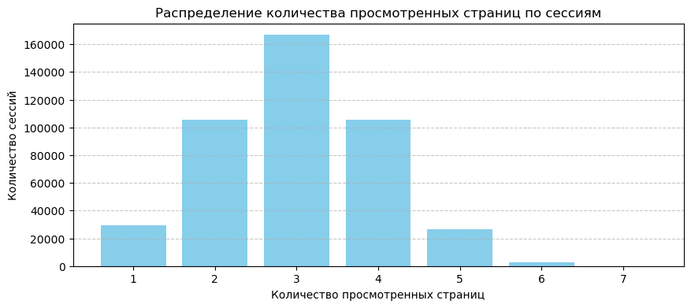

```python
# Строим столбчатую диаграмму
plt.figure(figsize=(10, 4))
plt.bar(page_views_stats["page_counter"], page_views_stats["session_count"], color="skyblue")

plt.xlabel("Количество просмотренных страниц")
plt.ylabel("Количество сессий")
plt.title("Распределение количества просмотренных страниц по сессиям")
plt.grid(axis="y", linestyle="--", alpha=0.7)

plt.show()
```

#### 1.5. Доля пользователей, просмотревших более четырёх страниц

Продуктовая команда продукта считает, что сессии, в рамках которых пользователь просмотрел 4 и более страниц, говорят об удовлетворённости контентом и алгоритмами рекомендаций. Этот показатель является важной прокси-метрикой для продукта.

- В датафрейме `sessions_history` создим дополнительный столбец `good_session`. В него войдёт значение `1`, если за одну сессию было просмотрено 4 и более страниц, и значение `0`, если было просмотрено меньше.
- Построим график со средним значением доли успешных сессий ко всем сессиям по дням за весь период наблюдения.

```python
# Создаем столбец good_session
sessions_history["good_session"] = (sessions_history["page_counter"] >= 4).astype(int)
sessions_history.head()
```

|  | user_id | session_id | session_date | session_start_ts | install_date | session_number | registration_flag | page_counter | region | device | good_session |
| --- | --- | --- | --- | --- | --- | --- | --- | --- | --- | --- | --- |
| 0 | E302123B7000BFE4 | F9AF61A0C2023832 | 2025-08-15 | 2025-08-15 17:47:35 | 2025-08-15 | 1 | 0 | 3 | CIS | iPhone | 0 |
| 1 | 2530F72E221829FB | 85003A206CBDAC6F | 2025-08-15 | 2025-08-15 16:42:14 | 2025-08-15 | 1 | 0 | 4 | MENA | Android | 1 |
| 2 | 876E020A4FC512F5 | 3677423E49D72DEE | 2025-08-15 | 2025-08-15 12:30:00 | 2025-08-15 | 1 | 0 | 4 | EU | PC | 1 |
| 3 | 2640B349E1D81584 | 956B45F5915CA225 | 2025-08-15 | 2025-08-15 15:31:31 | 2025-08-15 | 1 | 0 | 4 | CIS | Android | 1 |
| 4 | 94E1CBFAEF1F5EE9 | 83BF0DA35F9F1F40 | 2025-08-15 | 2025-08-15 21:33:53 | 2025-08-15 | 1 | 0 | 3 | CIS | Android | 0 |

```python
# Агрегируем данные: средняя доля успешных сессий по дням
daily_good_sessions = sessions_history.groupby("session_date")["good_session"].mean().reset_index()
daily_good_sessions.head()
```

|  | session_date | good_session |
| --- | --- | --- |
| 0 | 2025-08-11 | 0.312835 |
| 1 | 2025-08-12 | 0.302015 |
| 2 | 2025-08-13 | 0.306750 |
| 3 | 2025-08-14 | 0.316055 |
| 4 | 2025-08-15 | 0.304941 |

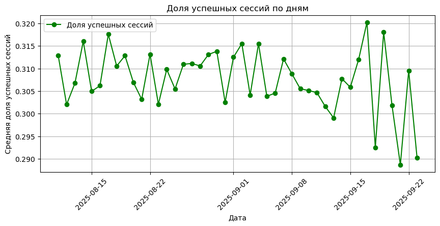

```python
# Строим график средней доли успешных сессий
plt.figure(figsize=(10, 4))
plt.plot(daily_good_sessions["session_date"], daily_good_sessions["good_session"], marker="o", color="green", label="Доля успешных сессий")

plt.xlabel("Дата")
plt.ylabel("Средняя доля успешных сессий")
plt.title("Доля успешных сессий по дням")
plt.legend()
plt.grid(True)
plt.xticks(rotation=45)

plt.show()
```

### 2. Подготовка к тесту

При планировании теста необходимо проделать несколько важных шагов:

- Определиться с целевой метрикой.
- Рассчитать необходимый размер выборки.
- Исходя из текущих значений трафика, рассчитать необходимую длительность проведения теста.

#### 2.1. Расчёт размера выборки

Для рассчёта размера выборки установим в коде ниже следующие параметры:

- Уровень значимости — 0.05.
- Вероятность ошибки второго рода — 0.2.
- Мощность теста.
- Минимальный детектируемый эффект, или MDE, — 3%.

При расчёте размера выборки мы будем использовать метод `solve_power()` из класса `power.NormalIndPower` модуля `statsmodels.stats`.

```python
from statsmodels.stats.power import NormalIndPower

# Задаём параметры
alpha = 0.05  # Уровень значимости
beta = 0.2  # Ошибка второго рода, часто 1 - мощность
power = 0.8  # Мощность теста
mde = 0.03  # Минимальный детектируемый эффект

# Инициализируем класс NormalIndPower
power_analysis = NormalIndPower()

# Рассчитываем размер выборки
sample_size = power_analysis.solve_power(
    effect_size = mde,
    power = power,
    alpha = alpha,
    ratio = 1 # Равномерное распределение выборок
)

print(f"Необходимый размер выборки для каждой группы: {int(sample_size)}")
```

```
Необходимый размер выборки для каждой группы: 17441
```

#### 2.1. Расчёт длительности A/B-теста

- Рассчитаем среднее количество уникальных пользователей приложения в день.
- Определим длительность теста, исходя из рассчитанного значения размера выборок и среднего дневного трафика приложения.

```python
# Считаем количество уникальных пользователей в каждый день
daily_users = sessions_history.groupby("session_date")["user_id"].nunique()
daily_users.head()
```

```
session_date
2025-08-11     3919
2025-08-12     6056
2025-08-13     8489
2025-08-14    10321
2025-08-15    14065
Name: user_id, dtype: int64
```

```python
import math
from math import ceil

# Среднее количество пользователей приложения в день по историческим данным
avg_daily_users = round(daily_users.mean())

# Рассчитываем длительность теста в днях как отношение размера выборки к среднему числу пользователей
test_duration = math.ceil(sample_size*2 / avg_daily_users)

print(f"Рассчитанная длительность A/B-теста при текущем уровене трафика в {avg_daily_users} пользователей в день составит {test_duration} дней")
```

```
Рассчитанная длительность A/B-теста при текущем уровене трафика в 9907 пользователей в день составит 4 дней
```

### 3. Мониторинг А/В-теста

#### 3.1. Проверка распределения пользователей

- Считаем и сохраним в датафрейм `sessions_test_part` CSV-файл с историческими данными о сессиях пользователей `sessions_project_test_part.csv`.
- Рассчитаем количество уникальных пользователей в каждой из экспериментальных групп для одного дня наблюдения.
- Рассчитаем и выведем на экран процентную разницу в количестве пользователей в группах A и B.

Для расчёта процентной разницы воспользуемся формулой: $$P = 100 \cdot \frac{|A − B|}{A}$$

```python
# Выгружаем данные в переменную
sessions_test_part = pd.read_csv('https://code.s3.yandex.net/datasets/sessions_project_test_part.csv')
sessions_test_part.head()
```

|  | user_id | session_id | session_date | session_start_ts | install_date | session_number | registration_flag | page_counter | region | device | test_group |
| --- | --- | --- | --- | --- | --- | --- | --- | --- | --- | --- | --- |
| 0 | 3404844B53442747 | B4901323BD537E45 | 2025-10-14 | 2025-10-14 19:28:49 | 2025-10-14 | 1 | 0 | 3 | CIS | Android | B |
| 1 | 3A2BF4D364E62D89 | 216FC619308F8788 | 2025-10-14 | 2025-10-14 21:11:04 | 2025-10-14 | 1 | 0 | 3 | MENA | iPhone | A |
| 2 | 79CDAE11E32B1597 | EDFCE4AC1A504074 | 2025-10-14 | 2025-10-14 21:44:03 | 2025-10-14 | 1 | 0 | 3 | CIS | iPhone | A |
| 3 | D6AF8D78297A931F | CF0AC0EEDE92C690 | 2025-10-14 | 2025-10-14 19:07:55 | 2025-10-14 | 1 | 0 | 4 | CIS | PC | A |
| 4 | 37E0CE723AE568E0 | 2E6ED45E8C86C4E9 | 2025-10-14 | 2025-10-14 15:39:44 | 2025-10-14 | 1 | 0 | 3 | CIS | Mac | B |

```python
#Рассчитаем количество уникальных пользователей в каждой из групп
unique_users = (sessions_test_part.groupby('test_group')['user_id'].nunique()
    .reset_index()
    .rename(columns={'user_id': 'unique_users_count'})
)

unique_users
```

|  | test_group | unique_users_count |
| --- | --- | --- |
| 0 | A | 1477 |
| 1 | B | 1466 |

```python
#Рассчитаем процентную разницу
a_users = unique_users[unique_users['test_group'] == 'A']['unique_users_count'].values[0]
b_users = unique_users[unique_users['test_group'] == 'B']['unique_users_count'].values[0]

p = 100 * (a_users - b_users) / a_users
print(f"Процентная разница: {p:.2f}%")
```

```
Процентная разница: 0.74%
```

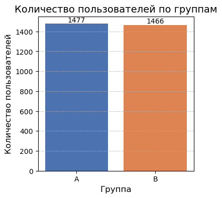

```python
# Строим визуализацию
groups = unique_users['test_group'].tolist()
counts = unique_users['unique_users_count'].tolist()

# Создаём столбчатую диаграмму
plt.figure(figsize=(4, 4))
bars = plt.bar(groups, counts, color=['#4C72B0', '#DD8452'])

# Добавляем подписи
plt.title('Количество пользователей по группам', fontsize=14)
plt.xlabel('Группа', fontsize=12)
plt.ylabel('Количество пользователей', fontsize=12)
plt.grid(axis='y', linestyle='--', alpha=0.7)

# Добавляем значения на столбцы
for bar in bars:
    height = bar.get_height()
    plt.text(bar.get_x() + bar.get_width()/2., height,
             f'{height}',
             ha='center', va='bottom')

plt.show()
```

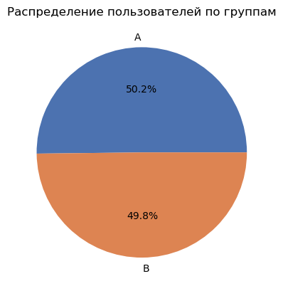

```python
plt.pie(counts, labels=groups, autopct='%1.1f%%', colors=['#4C72B0', '#DD8452'])
plt.title('Распределение пользователей по группам')
```

#### 3.2. Проверка пересечений пользователей

Помимо проверки равенства количества пользователей в группах полезно убедиться в том, что группы независимы. Для этого нужно убедиться, что никто из пользователей случайно не попал в обе группы одновременно.

- Рассчитаем количество пользователей, которые встречаются одновременно в группах A и B, или убедитесь, что таких нет.

```python
# Получаем уникальных пользователей из групп A и B
users_a = sessions_test_part[sessions_test_part['test_group'] == 'A']['user_id'].unique()
users_b = sessions_test_part[sessions_test_part['test_group'] == 'B']['user_id'].unique()

# Находим пересечение
intersection = list(set(users_a) & set(users_b))
# Выводим результат
if len(intersection) > 0:
    print(f"Найдено {len(intersection)} пользователей, присутствующих в обеих группах.")
    print("Список user_id:", intersection)
else:
    print("Пересечений между группами A и B нет.")
```

```
Пересечений между группами A и B нет.
```

#### 3.3. Равномерность разделения пользователей по устройствам

Полезно также убедиться в том, что пользователи равномерно распределены по всем доступным категориальным переменным — типам устройства и регионам.

Построим две диаграммы:

- доля каждого типа устройства для пользователей из группы A,
- доля каждого типа устройства для пользователей из группы B.

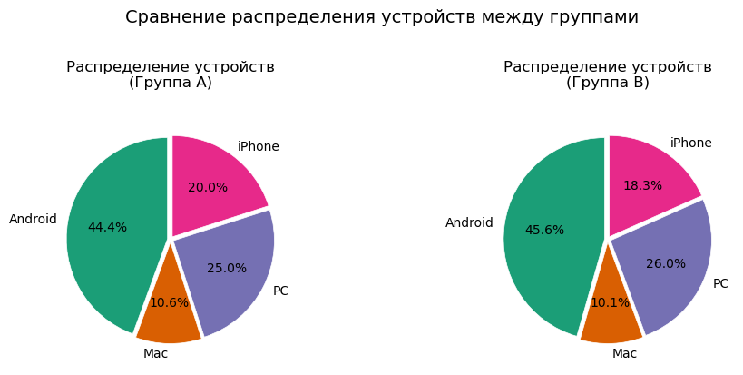

```python
def plot_device_distribution(group_name, data, ax):
    # Считаем количество уникальных пользователей по устройствам
    device_counts = data.groupby('device')['user_id'].nunique()

    # Параметры визуализации
    colors = plt.cm.Dark2.colors
    explode = [0.03] * len(device_counts)

    # Строим круговую диаграмму
    ax.pie(device_counts,
           labels=device_counts.index,
           autopct='%1.1f%%',
           startangle=90,
           colors=colors[:len(device_counts)],
           explode=explode,
           wedgeprops={'edgecolor': 'white', 'linewidth': 0.5})

    ax.set_title(f'Распределение устройств\n(Группа {group_name})', pad=20)

# Фильтруем данные для групп A и B
group_a = sessions_test_part[sessions_test_part['test_group'] == 'A']
group_b = sessions_test_part[sessions_test_part['test_group'] == 'B']

# Создаём подграфики
fig, (ax1, ax2) = plt.subplots(1, 2, figsize=(10, 4))

# Строим диаграммы
plot_device_distribution('A', group_a, ax1)
plot_device_distribution('B', group_b, ax2)

# Общие настройки
plt.suptitle('Сравнение распределения устройств между группами', y=1.02, fontsize=14)
plt.tight_layout()
plt.show()
```

#### 3.4. Равномерность распределения пользователей по регионам

Теперь убедимся, что пользователи равномерно распределены по регионам.

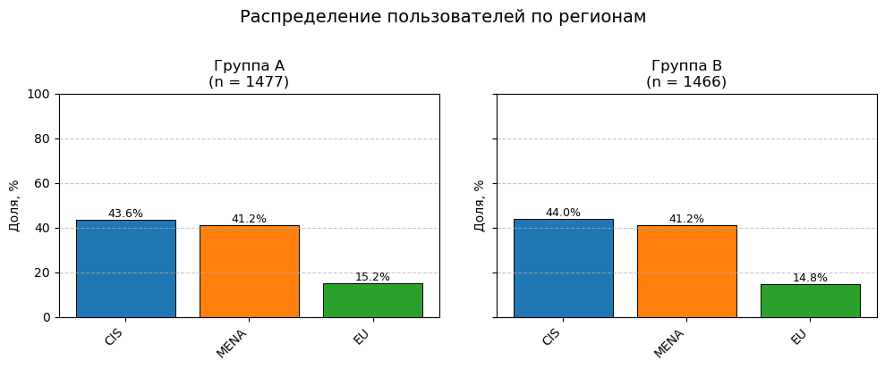

```python
import numpy as np
def plot_region_distribution(group_name, data, ax):
    # Считаем уникальных пользователей по регионам
    region_counts = data.groupby('region')['user_id'].nunique().sort_values(ascending=False)
    total_users = region_counts.sum()
    percentages = (region_counts / total_users * 100).round(1)

    # Параметры визуализации
    colors = plt.cm.tab10.colors[:len(region_counts)]
    x = np.arange(len(region_counts))

    # Строим столбчатую диаграмму
    bars = ax.bar(x, percentages, color=colors, edgecolor='black', linewidth=0.7)

    # Настройки осей
    ax.set_xticks(x)
    ax.set_xticklabels(region_counts.index, rotation=45, ha='right')
    ax.set_ylim(0, 100)
    ax.set_title(f'Группа {group_name}\n(n = {total_users})', fontsize=12)
    ax.set_ylabel('Доля, %', fontsize=10)
    ax.grid(axis='y', linestyle='--', alpha=0.7)

    # Добавляем значения на столбцы
    for bar in bars:
        height = bar.get_height()
        ax.text(bar.get_x() + bar.get_width()/2., height,
                f'{height}%',
                ha='center', va='bottom',
                fontsize=9)

# Фильтруем данные
group_a = sessions_test_part[sessions_test_part['test_group'] == 'A']
group_b = sessions_test_part[sessions_test_part['test_group'] == 'B']

# Создаём фигуру
fig, (ax1, ax2) = plt.subplots(1, 2, figsize=(10, 4), sharey=True)

# Строим диаграммы
plot_region_distribution('A', group_a, ax1)
plot_region_distribution('B', group_b, ax2)

# Общие настройки
plt.suptitle('Распределение пользователей по регионам', fontsize=14, y=1.02)
plt.tight_layout()
plt.subplots_adjust(wspace=0.15)
plt.show()
```

#### 3.5. Вывод после проверки A/B-теста

В ходе анализа A/B-теста выявили:

- Разница в количестве пользователей между группой A (1477) и группой B (1466) составляет 11 человек (менее 1% от общего числа). Статистически значимой разницы не обнаружено. Группы можно считать сопоставимыми по размеру.
- Выборки являются независимыми, пересечение пользователей между группами не обнаружено.
- Распределение пользователей по регионам и устроствам в группах A и B практически идентично. Это свидетельствует о равномерности распределения

Можно сделать вывод о корректности A/B-теста

### 4. Проверка результатов A/B-теста

A/B-тест завершён, есть результаты за все дни проведения эксперимента. Необходимо убедиться в корректности теста и верно интерпретировать результаты.

#### 4.1. Получение результатов теста и подсчёт основной метрики

- Считаем и сохраним в датафрейм `sessions_test` CSV-файл с историческими данными о сессиях пользователей `sessions_project_test.csv`.
- В датафрейме `sessions_test` создадим дополнительный столбец `good_session`. В него войдёт значение `1`, если за одну сессию было просмотрено 4 и более страниц, и значение `0`, если просмотрено меньше.

```python
# Выгружаем данные в переменную
sessions_test = pd.read_csv('https://code.s3.yandex.net/datasets/sessions_project_test.csv')
# Создаем столбец good_session
sessions_test["good_session"] = (sessions_test["page_counter"] >= 4).astype(int)
sessions_test.head()
```

|  | user_id | session_id | session_date | session_start_ts | install_date | session_number | registration_flag | page_counter | region | device | test_group | good_session |
| --- | --- | --- | --- | --- | --- | --- | --- | --- | --- | --- | --- | --- |
| 0 | 6DAE3B3654DA738E | C69249E26E58F6E2 | 2025-10-26 | 2025-10-26 18:15:05 | 2025-10-16 | 3 | 0 | 3 | MENA | Android | A | 0 |
| 1 | 0A3FE5D1DD59110A | 66D66D7C9F5181B7 | 2025-10-21 | 2025-10-21 17:04:53 | 2025-10-15 | 2 | 1 | 2 | CIS | Android | B | 0 |
| 2 | 2041F1D7AA740B88 | 50DE51D42215E74C | 2025-10-23 | 2025-10-23 17:39:29 | 2025-10-19 | 3 | 0 | 2 | MENA | Android | A | 0 |
| 3 | 43D7585009168086 | 5763C0C353C22263 | 2025-10-24 | 2025-10-24 15:01:57 | 2025-10-18 | 4 | 0 | 1 | CIS | iPhone | B | 0 |
| 4 | 15AD68B14D62D88C | B1AD09F93C1053BC | 2025-10-17 | 2025-10-17 17:34:39 | 2025-10-17 | 1 | 0 | 2 | MENA | Android | B | 0 |

#### 4.2. Проверка корректности результатов теста

Прежде чем приступать к анализу ключевых продуктовых метрик, необходимо убедиться, что тест проведён корректно и мы будем сравнивать две сопоставимые группы.

- Рассчитаем количество уникальных сессий для каждого дня и обеих тестовых групп, используя группировку.
- Проверим, что количество уникальных дневных сессий в двух выборках не различается или различия не статистически значимы.

```python
# Группировка и подсчёт уникальных сессий
result = sessions_test.groupby(['session_date', 'test_group'])['session_id'].nunique().reset_index()
result.columns = ['session_date', 'test_group', 'unique_sessions']
result
```

|  | session_date | test_group | unique_sessions |
| --- | --- | --- | --- |
| 0 | 2025-10-14 | A | 1502 |
| 1 | 2025-10-14 | B | 1628 |
| 2 | 2025-10-15 | A | 2235 |
| 3 | 2025-10-15 | B | 2283 |
| 4 | 2025-10-16 | A | 3280 |
| 5 | 2025-10-16 | B | 3241 |
| 6 | 2025-10-17 | A | 4089 |
| 7 | 2025-10-17 | B | 4054 |
| 8 | 2025-10-18 | A | 5013 |
| 9 | 2025-10-18 | B | 5059 |
| 10 | 2025-10-19 | A | 6535 |
| 11 | 2025-10-19 | B | 6779 |
| 12 | 2025-10-20 | A | 5837 |
| 13 | 2025-10-20 | B | 6089 |
| 14 | 2025-10-21 | A | 3927 |
| 15 | 2025-10-21 | B | 3981 |
| 16 | 2025-10-22 | A | 3083 |
| 17 | 2025-10-22 | B | 3111 |
| 18 | 2025-10-23 | A | 2470 |
| 19 | 2025-10-23 | B | 2548 |
| 20 | 2025-10-24 | A | 2090 |
| 21 | 2025-10-24 | B | 2068 |
| 22 | 2025-10-25 | A | 1897 |
| 23 | 2025-10-25 | B | 1814 |
| 24 | 2025-10-26 | A | 1669 |
| 25 | 2025-10-26 | B | 1692 |
| 26 | 2025-10-27 | A | 1454 |
| 27 | 2025-10-27 | B | 1517 |
| 28 | 2025-10-28 | A | 1279 |
| 29 | 2025-10-28 | B | 1289 |
| 30 | 2025-10-29 | A | 1068 |
| 31 | 2025-10-29 | B | 1131 |
| 32 | 2025-10-30 | A | 887 |
| 33 | 2025-10-30 | B | 876 |
| 34 | 2025-10-31 | A | 644 |
| 35 | 2025-10-31 | B | 669 |
| 36 | 2025-11-01 | A | 434 |
| 37 | 2025-11-01 | B | 465 |
| 38 | 2025-11-02 | A | 158 |
| 39 | 2025-11-02 | B | 160 |

Сформируем гипотезы и используем статистический тест, который позволит сделать вывод о равенстве средних двух выборок:

- Нулевая гипотеза (H0): Количество уникальных дневных сессий в двух выборках не различается или различия не статистически значимы.
- Альтернативная гипотеза (H1): Количество уникальных дневных сессий в двух выборках различаются.

```python
from scipy.stats import ttest_ind
# Разделение данных по группам
group_a = result[result['test_group'] == 'A']['unique_sessions']
group_b = result[result['test_group'] == 'B']['unique_sessions']

# Выполнение независимого t-теста
test_result = ttest_ind(group_a, group_b, alternative='two-sided')

alpha = 0.05
test_result.pvalue

if test_result.pvalue < alpha:
    print(f"Полученное значение p_value={test_result.pvalue} меньше критического уровня alpha={alpha}. Принимаем альтернативную гипотезу.")
else:
    print(f"Полученное значение p_value={test_result.pvalue} больше критического уровня alpha={alpha}. Опровергнуть нулевую гипотезу нельзя.")
```

```
Полученное значение p_value=0.9382193048591161 больше критического уровня alpha=0.05. Опровергнуть нулевую гипотезу нельзя.
```

#### 4.3. Сравнение доли успешных сессий

Мы убедились, что количество сессий в обеих выборках не различалось, можно переходить к анализу ключевой метрики — доли успешных сессий.

Используем созданный на первом шаге задания столбец `good_session` и рассчитаем долю успешных сессий для выборок A и B, а также разницу в этом показателе. Полученный вывод отобразим на экране.

```python
# Рассчитываем долю успешных сессий
result = sessions_test.groupby('test_group')['good_session'].agg(
    total_sessions='count',
    good_sessions='sum'
)
result['proportion'] = result['good_sessions'] / result['total_sessions'] * 100
result = result.round(2)
result
```

| test_group | total_sessions | good_sessions | proportion |
| --- | --- | --- | --- |
| A | 49551 | 15248 | 30.77 |
| B | 50454 | 16059 | 31.83 |

```python
# Вычисляем разницу между группами
diff = result.loc['B', 'proportion'] - result.loc['A', 'proportion']

# Выводим результат
print(f"Разница (B - A): {diff:.2f}%")
```

```
Разница (B - A): 1.06%
```

#### 4.4. Насколько статистически значимо изменение ключевой метрики

На предыдущем шаге мы убедились, что количество успешных сессий в тестовой выборке примерно на 1.1% выше, чем в контрольной, но делать выводы только на основе этого значения будет некорректно. Для принятия решения всегда необходимо отвечать на вопрос: является ли это изменение статистически значимым.

- Используя статистический тест, рассчитаем, является ли изменение в метрике доли успешных сессий статистически значимым.

Сформулируем гипотезы:

- Нулевая гипотеза (H0): Доли успешных сессий в группах A и B равны.
- Альтернативная гипотеза (H1): Доли успешных сессий различаются.

```python
# Считаем успехи и общее количество для каждой группы
success_a = sessions_test[sessions_test['test_group'] == 'A']['good_session'].sum()
total_a = (sessions_test['test_group'] == 'A').sum()

success_b = sessions_test[sessions_test['test_group'] == 'B']['good_session'].sum()
total_b = (sessions_test['test_group'] == 'B').sum()

# Выполняем Z-тест для двух пропорций
from statsmodels.stats.proportion import proportions_ztest
z_stat, p_value = proportions_ztest(
    count=[success_a, success_b],
    nobs=[total_a, total_b],
    alternative='two-sided'
)

# Выводим результаты
print(f"Группа A: {success_a}/{total_a} ({success_a/total_a:.2%})")
print(f"Группа B: {success_b}/{total_b} ({success_b/total_b:.2%})")
print(f"\nP-value: {p_value:.4f}")

alpha = 0.05
if p_value < alpha:
    print("\nВывод: Отвергаем нулевую гипотезу (различия статистически значимы)")
else:
    print("\nВывод: Не отвергаем нулевую гипотезу (различия не значимы)")
```

```
Группа A: 15248/49551 (30.77%)
Группа B: 16059/50454 (31.83%)

P-value: 0.0003

Вывод: Отвергаем нулевую гипотезу (различия статистически значимы)
```

#### 4.5. Вывод по результатам A/B-эксперимента

На основе проведённого анализа результатов теста можно сформулировать следующие выводы для команды разработки приложения:

Рекомендации для команды:

- Внедрить алгоритм, так как его эффективность подтверждена статистически.
- Провести дополнительный анализ для понимания причин расхождения с MDE (например, уточнить расчёт MDE, проверить корректность метрики, оценить долгосрочный эффект).
- Мониторить результаты после внедрения, чтобы убедиться в стабильности улучшений.

Вывод: Новый алгоритм показал статистически значимое улучшение ключевой метрики, что оправдывает его внедрение в текущую версию приложения.

В начало